# handin

## Data Mining

### Data Cleaning

Often the data acquired isnt clean and not easy to work with. This includes missing values, outliers or if its user generated then spelling mistakes too. Then there are different approaches to make the data more compareable. If the data follows the normal distribution and we want to use statistical models that expect it, standardization is the common approach. Otherwise normalization is most used to make data more comparable. Standardization isnt prone to outliers so the removal of these as a first stage can be skipped too.

### Feature Extraction

A important aspect of data mining is reducing the necessary features to describe a large set of the data.

### Feature Selection

Feature selection is a critical part in data mining due to numerous reasons. Since only relevant features are being looked at the data set reduces it dimensionality and is more efficient, accurate and less prone to over-fitting. Furthermore less features mean, that results can be easier interpreted. As can be seen in this figure explaining the Hughes phenomenon , a higher amount of features can make the model worse. More features can introduce noise, which can then lead to a decrease in classification accuracy.

[figure not shown]

*Hughes phenomenon, a increase of number of features decreases the accuracy of the classification model. Figure from [Weinmann(2019)](http://www.eurosdr.net/sites/default/files/images/inline/05-2019-12-04_presentation_pcp_workshop_weinmann.pdf).*

There are three notable categories of feature selection.

Filter-based methods that include statistical tests to assess the correlation between various features. These filters also remove features with low variance, since they are deemed to have little information. Because they are classifier-independent, simple and efficient they are often used. Alternativley Wrapper-based methods or Embedded methods can be used.

### Model Selection

There are two overarching themes when selecting a model. Either classification models or regression models. classification models include Decision trees, Support Vector machines and Clustering. Linear regression is the most used model in regression models but serveral others like multiple regression, logistic regression or Lasso regression.

Linear regression models describe a function that models the correlation of a variable of intrest and a dependent variable.

### Model training

Models are prone to be overfitted if too many features are selected, there isnt sufficient data to train the model or if the data is noisy. This noise can easily be treated as a pattern by the model. In order to detect overfitting the data set is split into training and validation set. After training, the model is given the validation set and the perfomance is tracked. If they diverge then the model is overfitting. But neither is underfitting desirable. If the model is underfitting then thers no information gain with the model. This requires the usage of additional features to enforce learning or to tighten the learning alogrithm.

### Model evaluation

- Accuracy

How often is the model correct

- Precision

Measures quality of positive predictions

- Recall

How many correct predictions are being made

- F1-score

Harmonic mean of precision and recall

## geospatial data analysis

In the following we showcase a typical workflow for classification that involves first having a point cloud that can be exapnded by co-registration. Then neighborhood selection, followed by feature extraction and feature selection. Lastly we choose our classification model.

### Co-registration

When working with point cloud data there might be two acquisitions from the same structure so co-Registration aims to combine the multiple point clouds of interest. Typical algorithms include Iterative closest point alogrithm or feature based matching algorithms.

[figure not shown]

*Co-Registration of two point clouds, showing the Arc de triomphe from different angles. Here a feature based matching algorithm, along the corners of the building, might be more computationaly efficient. Figure from [thinkautomonous](https://www.thinkautonomous.ai/blog/point-cloud-registration).*

As can be seen in this image, with two point clouds of the arc de triomphe in paris, the co-registrated point cloud has more information about the subject of interest. Often co-registration is conducted to detect changes in the area, for example after natural disasters or after longer periods of time to show change in the scanned area.

The following code provided by E-Trainee in module 3 shows code to read_las files with additional functionality and then registers two point-clouds from the hellstugubrean glacier. They are then shown with the python module polyscope.

```python
# import required modules
import laspy # import the laspy package for handling point cloud files
import numpy as np # import numpy for array handling

def read_las(infile,get_attributes=False,use_every=1):
    """
    Function to read coordinates and optionally attribute information of point cloud data from las/laz file.

    :param infile: specification of input file (format: las or laz)
    :param get_attributes: if True, will return all attributes in file, otherwise will only return coordinates (default is False)
    :param use_every: value specifies every n-th point to use from input, i.e. simple subsampling (default is 1, i.e. returning every point)
    :return: Array of point coordinates of shape (N,3) with N number of points in input file (or subsampled by 'use_every')
    """

    # read the file using the laspy read function
    indata = laspy.read(infile)

    # get the coordinates (XYZ) and stack them in a 3D array
    coords = np.vstack((indata.x, indata.y, indata.z)).transpose()

    # subsample the point cloud, if use_every = 1 will remain the full point cloud data
    coords = coords[::use_every, :]

    # read attributes if get_attributes is set to True
    if get_attributes == True:
        # get all attribute names in the las file as list
        las_fields= list(indata.points.point_format.dimension_names)

        # create a dictionary to store attributes
        attributes = {}

        # loop over all available fields in the las point cloud data
        for las_field in las_fields[3:]: # skip the first three fields, which contain coordinate information (X,Y,Z)
            attribute = np.array(indata.points[las_field]) # transpose shape to (N,1) to fit coordinates array
            if np.sum(attribute)==0: # if field contains only 0, it is empty
                continue
            # add the attribute to the dictionary with the name (las_field) as key
            attributes[las_field] = attribute[::use_every] # subsample by use_every, corresponding to point coordinates

        # return coordinates and attribute data
        return coords, attributes

    else: # get_attributes == False
        return coords  # return coordinates only

import polyscope as ps


DATA_PATH = '../module3/hellstugubrean'

# check if the specified data path exists
import os
if not os.path.isdir(DATA_PATH):
    print(f'ERROR: {DATA_PATH} does not exist')
    print('Please specify the correct path to the data directory.')

# read data, but only every 100th point (for quick visualisation)
data_2009 = read_las(DATA_PATH + "/hellstugubrean_2009.las", use_every=100, get_attributes=True)
data_2017 = read_las(DATA_PATH + "/hellstugubrean_2017.las", use_every=100, get_attributes=True)
```

[output not shown]

```python
# start up polyscope
ps.init()
pc_2009 = ps.register_point_cloud("point cloud 2009", data_2009[0])
# for the ALS point cloud, add the Intensity as a scalar value
pc_2009.add_scalar_quantity('Intensity', data_2009[1]["intensity"])
pc_2017 = ps.register_point_cloud("point cloud 2017", data_2017[0])
# for the DIM point cloud, add RGB attributes. We need to provide them as a Nx3 array, so we stack red, green and blue together.
# furthermore, they need to be values between 0 and 1, but are "unsigned integer with 16 bit", i.e. values between 0 and 65535.
pc_2017.add_color_quantity('RGB', np.array([data_2017[1]["red"], data_2017[1]["green"], data_2017[1]["blue"]]).T / 65535)
ps.set_up_dir("z_up")
ps.show()
```

```
[polyscope] Backend: openGL3_glfw -- Loaded openGL version: 4.1 INTEL-16.5.14
```

[output not shown]

[output not shown]

[figure not shown]

Visualized with polyscope showing the two glacier point clouds in the same coordinate system. The point cloud from 2009 is colored in blue and the same glacier from 2017 colored in yellow. Figure from author.

E-Trainee explains that the difference in height between the two point clouds, which can be seen most clearly in the centre of the image, is due to a "significan[t] loss of mass from the glacier over these 8 years".

### Segmentation

Multiple homogenous regions or clusters with similar properties. There are different approaches to do this. Firstly euclidean clustering, then k-nearest neighbors and lastly spatial neighborhoods.

### Neighborhood selection

When working with point cloud data calculations based on neighborhoods are among the most important ones.  
They are necessary for any filtering, smoothing or interpolation step and for information extraction.

Spatial neighborhoods are defined either by a certain distance to other points or to a certain amount of fixed neighbors Weinmann et. al.,2015 If its a certain distance then its considered a cylindircal neighborhood since it runs along the x and y axis. Otherwise if its 3D then they are called spherical neighborhoods because their height is also relevant. A point cloud neighborhood can also be defined by the fixed amount of neighbors. Fixed neighbors are also commonly called k-nearest neighbors and the size can be highly variable depending on the point density at that area.

Various forms of information can be supplied by a spatial neighborhood. A easily obtainable one is the point density. With the following formula the amount of points contained inside of a 1 m radius can be calculated. $$ D = {k+1 \over {4 \over 3} \pi r{^3}_{kNN}} $$

With this information outliers can be removed easily through statistical outlier removal provided by the Point Cloud Library.

### Feature Extraction

When working with point cloud data there are various features that are important. It always depends on the use case. 3D-features can be calculated by using eigenvalues or looking at the geometric properties. With neighborhoods local surface roughness can be derived.

[figure not shown]

*Features that can be easily derived from eigenwerte. Figure from [Weinmann(2019)](http://www.eurosdr.net/sites/default/files/images/inline/05-2019-12-04_presentation_pcp_workshop_weinmann.pdf).*

Ground removal is a important procedure when working with point cloud data. Ground points are always static, so its not wroth processing these, using up time and computing power. Notable algortihms are RANSAC (Random Sample Consensus), Ground Plane Fitting and Patchwork++.

[figure not shown]

*Showcasing different ground removal algorithms and patchwork++ being shown as the least prone to over and underfitting. Figure from [Seungjae Lee and Hyungtae Lim and Hyun Myung (2022)](https://arxiv.org/abs/2207.11919).*

### Classification

The extracted features can then be used as input for classifieres that have been trained with representable data. Different classifiers can be used like, Random Forest, Support Vector Machines, Nearest Neighbor classifiers, Decision Tree, naïve bayesian classifier or Linear Discriminant Analysis.

## Point-Cloud-Data Workflow

```python
import laspy
import numpy as np
```

#### Importing our Point-Cloud-Data

This data is imported from [G-LiHT](https://glihtdata.gsfc.nasa.gov/)  
And was then converted to .las format.  
.laz files can be used if laztools or lazrs are installed as backend.

```python
las = laspy.read('Wertheim_Jun2016_c1r0.las')
list(las.point_format.dimension_names)
```

```
['X',
 'Y',
 'Z',
 'intensity',
 'return_number',
 'number_of_returns',
 'scan_direction_flag',
 'edge_of_flight_line',
 'classification',
 'synthetic',
 'key_point',
 'withheld',
 'scan_angle_rank',
 'user_data',
 'point_source_id',
 'gps_time']
```

```python
las.X
```

```
array([54584, 54552, 54525, ..., 50968, 50528, 50905], dtype=int32)
```

```python
las.intensity
```

```
array([   0, 1769,    0, ...,    0,    0,    0], dtype=uint16)
```

```python
las.gps_time
```

```
array([62700.312283, 62700.322308, 62700.322312, ..., 65997.252258,
       65997.252261, 65997.262269])
```

#### PCD Classifications

With LAS 1.1-1.4 Specification there are defined categorys.

[figure not shown]

[More Details](https://desktop.arcgis.com/en/arcmap/latest/manage-data/las-dataset/lidar-point-classification.html)

```python
set(list(las.classification))
```

```
{1, 2}
```

### Feature Selection

```python
ground = las.points[las.classification==2]
print("%i points out of %i were ground points." % (len(ground),
        len(las.points)))
```

```
5768386 points out of 19200669 were ground points.
```

```python
point_data = np.vstack([las.X,las.Y,las.Z]).transpose((1,0))
```

```python
first_point = point_data[0,:]

distances = np.sqrt(np.sum((point_data - first_point) ** 2, axis=1))

mask = distances < 500

points_kept = las.points[mask]

print("We kept %i points out of %i total" % (len(points_kept), len(las.points)))
```

```
We kept 1080 points out of 19200669 total
```

Here we calculate the k nearest neighbors

```python
from scipy.spatial import KDTree
tree = KDTree(point_data)
neighbors_distance, neighbors_indices = tree.query(point_data[100], k=5)
print(neighbors_indices)
print(neighbors_distance)
```

```
[100 101  98 124 126]
[ 0.         27.82085549 28.44292531 40.16217126 41.23105626]
```

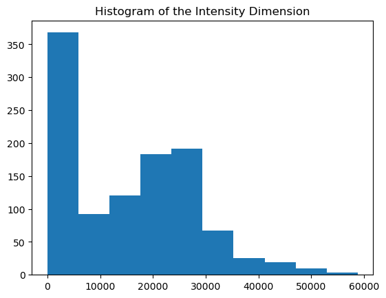

```python
import matplotlib.pyplot as plt
plt.hist(points_kept.intensity)
plt.title("Histogram of the Intensity Dimension")
plt.show()
```

```python
from sklearn.feature_selection import VarianceThreshold

# Print the original data
print("Original Data:")
print(point_data)

# Step 1: Calculate variance of each feature
variances = np.var(point_data, axis=0)
print("\nVariance of each feature:")
print(variances)

# Step 2: Determine an appropriate threshold
# You can start with a threshold slightly lower than the smallest variance you want to keep
# For example, if you want to remove features with variance less than 5000000
threshold = 1000000  # Adjust this value based on your variance analysis

# Step 3: Apply Variance Threshold
selector = VarianceThreshold(threshold=threshold)
filtered_data = selector.fit_transform(point_data)

# Print the selected features and filtered data
print("\nSelected Features Mask:")
print(selector.get_support())

print("\nFiltered Data:")
print(filtered_data)
```

```
Original Data:
[[54584  6509   825]
 [54552  6538   818]
 [54525  6516   833]
 ...
 [50968  6704   935]
 [50528  6511  1719]
 [50905  6610   927]]

Variance of each feature:
[7.27683094e+08 5.19919918e+08 4.97615240e+05]

Selected Features Mask:
[ True  True False]

Filtered Data:
[[54584  6509]
 [54552  6538]
 [54525  6516]
 ...
 [50968  6704]
 [50528  6511]
 [50905  6610]]
```

## references

- https://3dgeo-heidelberg.github.io/etrainee/module3/05_pointcloud_machine_learning/05_pointcloud_machine_learning.html